# Logistic regression

## Data Set Information:

This data approach student achievement in secondary education of two Portuguese schools. The data attributes include student grades, demographic, social and school related features) and it was collected by using school reports and questionnaires. Two datasets are provided regarding the performance in two distinct subjects: Mathematics (mat) and Portuguese language (por). In [Cortez and Silva, 2008], the two datasets were modeled under binary/five-level classification and regression tasks. Important note: the target attribute G3 has a strong correlation with attributes G2 and G1. This occurs because G3 is the final year grade (issued at the 3rd period), while G1 and G2 correspond to the 1st and 2nd period grades. It is more difficult to predict G3 without G2 and G1, but such prediction is much more useful (see paper source for more details).

Source:

Paulo Cortez, University of Minho, GuimarÃ£es, Portugal, http://www3.dsi.uminho.pt/pcortez

Relevant Papers:

P. Cortez and A. Silva. Using Data Mining to Predict Secondary School Student Performance. In A. Brito and J. Teixeira Eds., Proceedings of 5th FUture BUsiness TEChnology Conference (FUBUTEC 2008) pp. 5-12, Porto, Portugal, April, 2008, EUROSIS, ISBN 978-9077381-39-7.

Let’s start working!

```r
# read the data into memory
alc <- read.csv("C:/Users/juusov/Documents/IODS-project/Data/alc.csv", header = TRUE, sep = ",")
# print out the names of the variables in the data
names(alc)
```

```
##  [1] "school"     "sex"        "age"        "address"    "famsize"
##  [6] "Pstatus"    "Medu"       "Fedu"       "Mjob"       "Fjob"
## [11] "reason"     "nursery"    "internet"   "guardian"   "traveltime"
## [16] "studytime"  "failures"   "schoolsup"  "famsup"     "paid"
## [21] "activities" "higher"     "romantic"   "famrel"     "freetime"
## [26] "goout"      "Dalc"       "Walc"       "health"     "absences"
## [31] "G1"         "G2"         "G3"         "alc_use"    "high_use"
```

## Exploring the data

My aim is find out how age, free time after school, current health status, and number of school absences associated with high/low alcohol consumption among students. **My hypothesis is that among heavy drinkers (who are more frequently men than women) have more school absences and free time, they are older, and they have poorer perceived health.** Let’s pick the variables we’re interested in and look at some basic statistics.

```r
# access the tidyverse libraries dplyr, ggplot2, corrplot, and boot
library(tidyr); library(dplyr); library(ggplot2); library(corrplot); library(boot)
# produce mean statistics by group
alc %>% group_by(sex, high_use) %>% summarise(count = n(), mean_age = mean(age), mean_free_time = mean(freetime), mean_health = mean(health), mean_absence = mean(absences))
```

```
## # A tibble: 4 x 7
## # Groups:   sex [2]
##   sex   high_use count mean_age mean_free_time mean_health mean_absence
##   <fct> <lgl>    <int>    <dbl>          <dbl>       <dbl>        <dbl>
## 1 F     FALSE      156     16.6           2.93        3.38         4.22
## 2 F     TRUE        42     16.5           3.36        3.40         6.79
## 3 M     FALSE      112     16.3           3.39        3.71         2.98
## 4 M     TRUE        72     17.0           3.5         3.88         6.12
```

Results are grouped by sex and high/low alcohol consumption among students. We can see that among female there is 156 low/moderate drinkers and 42 heavy drinkers. Respectively in men there 112 low/moderate drinkers and 72 heavy users. Forunately in both sex there is more low/moderate drinkers than heavy drinkers. See other details from above.

## Boxplots

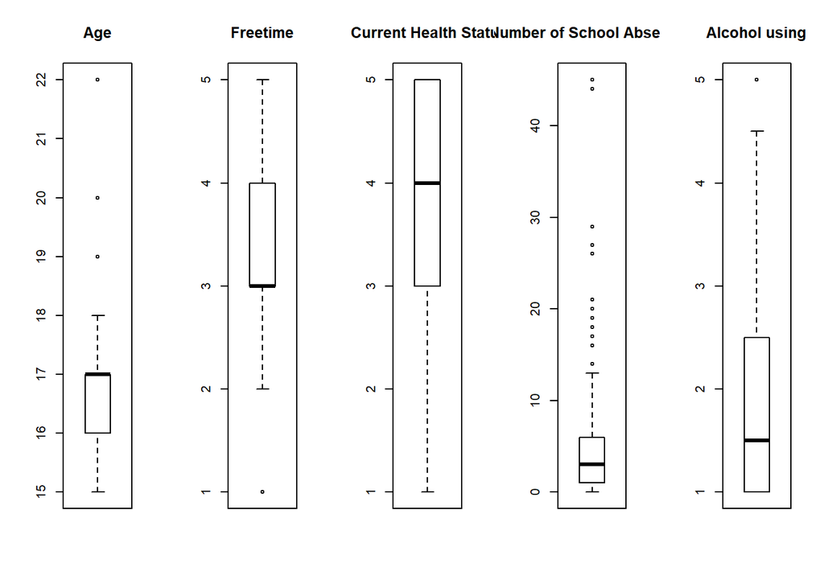

```r
# boxplots all populatio
par(mfrow=c(1,5))
boxplot(alc$age, main="Age")
boxplot(alc$freetime, main="Freetime")
boxplot(alc$health, main=" Current Health Status")
boxplot(alc$absences, main="Number of School Absences")
boxplot(alc$alc_use, main="Alcohol using")
```

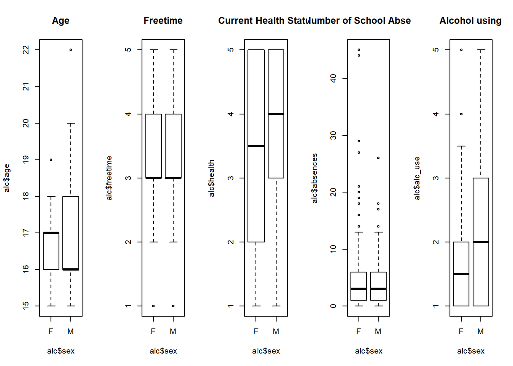

```r
# boxplots by sex
par(mfrow=c(1,5))
boxplot(alc$age~alc$sex, main="Age")
boxplot(alc$freetime~alc$sex, main="Freetime")
boxplot(alc$health~alc$sex, main=" Current Health Status")
boxplot(alc$absences~alc$sex, main="Number of School Absences")
boxplot(alc$alc_use~alc$sex, main="Alcohol using")
```

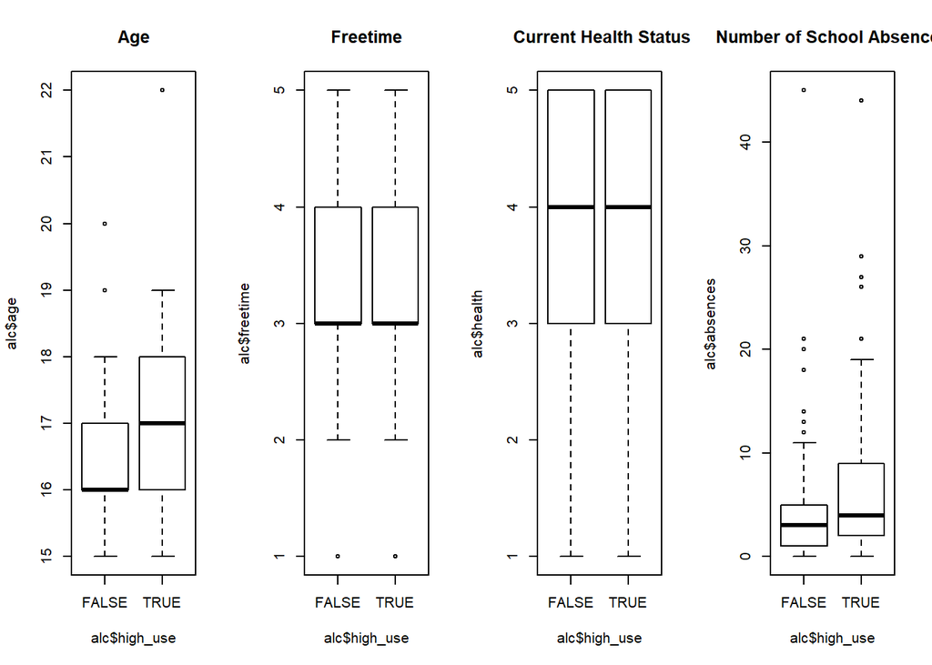

```r
# boxplots by alcohol high use
par(mfrow=c(1,4))
boxplot(alc$age~alc$high_use, main="Age")
boxplot(alc$freetime~alc$high_use, main="Freetime")
boxplot(alc$health~alc$high_use, main=" Current Health Status")
boxplot(alc$absences~alc$high_use, main="Number of School Absences")
```

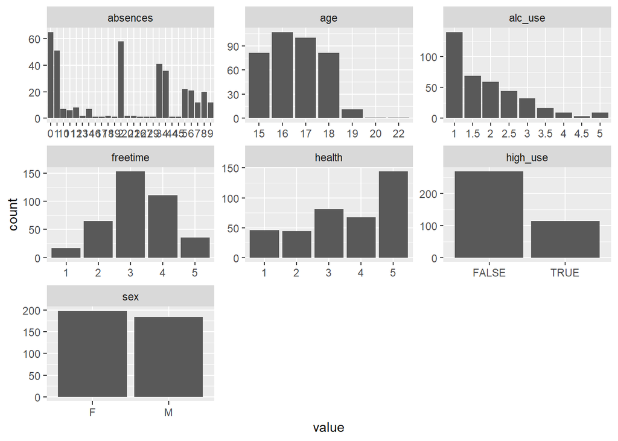

```r
# choose columns to keep for the analyses
keep_columns <- c("age", "sex", "freetime", "health", "absences", "alc_use", "high_use")

# select the 'alc_subset' to create a new dataset
alc_subset <- dplyr::select(alc, one_of(keep_columns))

# draw a bar plot of each variable
gather(alc_subset) %>% ggplot(aes(value)) + facet_wrap("key", scales = "free") + geom_bar()
```

## Logistic regression analyses

```r
# model with glm
m <- glm(alc_subset$high_use ~ alc_subset$age + alc_subset$sex + alc_subset$freetime + alc_subset$health + alc_subset$absences, data = alc, family = "binomial")

#print out summary
summary(m)
```

```
##
## Call:
## glm(formula = alc_subset$high_use ~ alc_subset$age + alc_subset$sex +
##     alc_subset$freetime + alc_subset$health + alc_subset$absences,
##     family = "binomial", data = alc)
##
## Deviance Residuals:
##     Min       1Q   Median       3Q      Max
## -2.1098  -0.8203  -0.6121   1.0681   2.0876
##
## Coefficients:
##                     Estimate Std. Error z value Pr(>|z|)
## (Intercept)         -5.94027    1.81093  -3.280 0.001037 **
## alc_subset$age       0.18163    0.10220   1.777 0.075542 .
## alc_subset$sexM      0.86250    0.24770   3.482 0.000498 ***
## alc_subset$freetime  0.28776    0.12533   2.296 0.021677 *
## alc_subset$health    0.05873    0.08800   0.667 0.504507
## alc_subset$absences  0.09335    0.02301   4.058 4.95e-05 ***
## ---
## Signif. codes:  0 '***' 0.001 '**' 0.01 '*' 0.05 '.' 0.1 ' ' 1
##
## (Dispersion parameter for binomial family taken to be 1)
##
##     Null deviance: 465.68  on 381  degrees of freedom
## Residual deviance: 420.99  on 376  degrees of freedom
## AIC: 432.99
##
## Number of Fisher Scoring iterations: 4
```

```r
# compute odds ratios (OR)
OR <- coef(m) %>% exp

# compute confidence intervals (CI)
CI <- confint(m) %>% exp
# print out the odds ratios with their confidence intervals
cbind(OR, CI)
```

```
##                              OR        2.5 %     97.5 %
## (Intercept)         0.002631321 7.021357e-05 0.08669783
## alc_subset$age      1.199171825 9.830119e-01 1.46888737
## alc_subset$sexM     2.369086597 1.464751e+00 3.87560256
## alc_subset$freetime 1.333435235 1.045768e+00 1.71125765
## alc_subset$health   1.060491092 8.937200e-01 1.26298969
## alc_subset$absences 1.097850460 1.051579e+00 1.15103254
```

“When a logistic regression is calculated, the regression coefficient (b1) is the estimated increase in the log odds of the outcome per unit increase in the value of the exposure. In other words, the exponential function of the regression coefficient (eb1) is the odds ratio associated with a one-unit increase in the exposure. An odds ratio (OR) is a measure of association between an exposure and an outcome. The OR represents the odds that an outcome will occur given a particular exposure, compared to the odds of the outcome occurring in the absence of that exposure.” (Szumilas M. Explaining odds ratios [published correction appears in J Can Acad Child Adolesc Psychiatry. 2015 Winter;24(1):58]. J Can Acad Child Adolesc Psychiatry. 2010;19(3):227–229.)

## Results of logistic regression model

Let’s look at coefficients first. In this case sex, freetime, and school absences significantly associated with alchol high use. If we look at the odds ratios (OR). We can conclude that sex increase 2.36 (136%) times, freetime 1.33 (33%) times, and school absences 1.09 (9%) times risk for alcohol high use. This analysis get us closer to final conclusion. **The hypothesis is still alive partly, now we can say that sex, freetime and school absences statistically associated with higher alcohol consumption in this population.**

## Prediction and validation

```r
#fit the model
m2 <- glm(high_use ~ sex + freetime + absences, data = alc_subset, family = "binomial")

# predict() the probability of high_use
probabilities <- predict(m2, type = "response")

# add the predicted probabilities to 'alc_subset'
alc_subset <- mutate(alc_subset, probability = probabilities)

# use the probabilities to make a prediction of high_use
alc_subset <- mutate(alc_subset, prediction = probability > 0.5)

# see the last ten original classes, predicted probabilities, and class predictions
select(alc_subset, sex, freetime, absences, high_use, probability, prediction) %>% tail(20)
```

```
##     sex freetime absences high_use probability prediction
## 363   F        4        8    FALSE  0.30998649      FALSE
## 364   F        5        9    FALSE  0.39835071      FALSE
## 365   F        4        0    FALSE  0.17042678      FALSE
## 366   F        3        3    FALSE  0.17090391      FALSE
## 367   F        4        2     TRUE  0.19988715      FALSE
## 368   F        1        0    FALSE  0.07923997      FALSE
## 369   F        5       14     TRUE  0.51915876       TRUE
## 370   M        2        4     TRUE  0.28999668      FALSE
## 371   M        4        2    FALSE  0.37497539      FALSE
## 372   M        4        3    FALSE  0.39816238      FALSE
## 373   M        3        0    FALSE  0.26961553      FALSE
## 374   M        4        7     TRUE  0.49452118      FALSE
## 375   F        3        1    FALSE  0.14494141      FALSE
## 376   F        4        6    FALSE  0.26977031      FALSE
## 377   F        4        2    FALSE  0.19988715      FALSE
## 378   F        3        2    FALSE  0.15748815      FALSE
## 379   F        2        2    FALSE  0.12270339      FALSE
## 380   F        1        3    FALSE  0.10346444      FALSE
## 381   M        4        4     TRUE  0.42181554      FALSE
## 382   M        4        2     TRUE  0.37497539      FALSE
```

```r
# initialize a plot of 'high_use' versus 'probability' in 'alc_subset'
g <- ggplot(alc_subset, aes(x = probability, y = high_use, col = prediction))

# define the geom as points and draw the plot
geom_point(col = 'prediction')
```

```
## geom_point: na.rm = FALSE
## stat_identity: na.rm = FALSE
## position_identity
```

[figure not shown]

```r
g
```

```r
# tabulate the target variable versus the predictions
table(high_use = alc_subset$high_use, prediction = alc_subset$prediction)%>%prop.table()%>%addmargins()
```

```
##         prediction
## high_use      FALSE       TRUE        Sum
##    FALSE 0.66492147 0.03664921 0.70157068
##    TRUE  0.23036649 0.06806283 0.29842932
##    Sum   0.89528796 0.10471204 1.00000000
```

```r
# define a loss function (average prediction error)
loss_func <- function(class, prob) {
  n_wrong <- abs(class - prob) > 0.5
  mean(n_wrong)
}

# call loss_func to compute the average number of wrong predictions in the data
loss_func(class = alc_subset$high_use, prob = alc_subset$probability)
```

```
## [1] 0.2670157
```

```r
# K-fold cross-validation
cv <- cv.glm(data = alc_subset, cost = loss_func, glmfit = m, K = 10)

# average number of wrong predictions in the cross validation
cv$delta[1]
```

```
## [1] 0.3449261
```